# Block 2 ex 3

Facchin Tommaso

Male inhabitants of the Greek island of Kalythos suffer from a congenital eye disease, whose effects become more pronounced at older ages. In a sample of male islanders of different ages, the number of blind individuals was recorded. The code creates a dataset for the observed data by defining one variable for the total number of men sampled at each age and another variable for the number of blind men identified in the sample.

```r
Kalythos <- data.frame(age = c(20,35,45,55,70),
                       total_sample = c(50,50,50,50,50),
                       n_blind = c(6,17,26,37,44))
```

### 1. Estimate a model that investigates whether the proportion of blind people on the island changes as a function of individuals’ age. Use the canonical link function.

```r
Kalythos$Y <- cbind(Kalythos$n_blind,
                    Kalythos$total_sample - Kalythos$n_blind)

fit <- glm(Y ~ age, family = binomial, data = Kalythos)
summary(fit)
```

```
##
## Call:
## glm(formula = Y ~ age, family = binomial, data = Kalythos)
##
## Coefficients:
##             Estimate Std. Error z value Pr(>|z|)
## (Intercept) -3.53778    0.50232  -7.043 1.88e-12 ***
## age          0.08114    0.01082   7.498 6.47e-14 ***
## ---
## Signif. codes:  0 '***' 0.001 '**' 0.01 '*' 0.05 '.' 0.1 ' ' 1
##
## (Dispersion parameter for binomial family taken to be 1)
##
##     Null deviance: 82.14455  on 4  degrees of freedom
## Residual deviance:  0.31707  on 3  degrees of freedom
## AIC: 24.132
##
## Number of Fisher Scoring iterations: 4
```

### 2. Create a plot showing the relationship estimated by the model from the previous point, and comment on how well the fitted model matches the collected data.

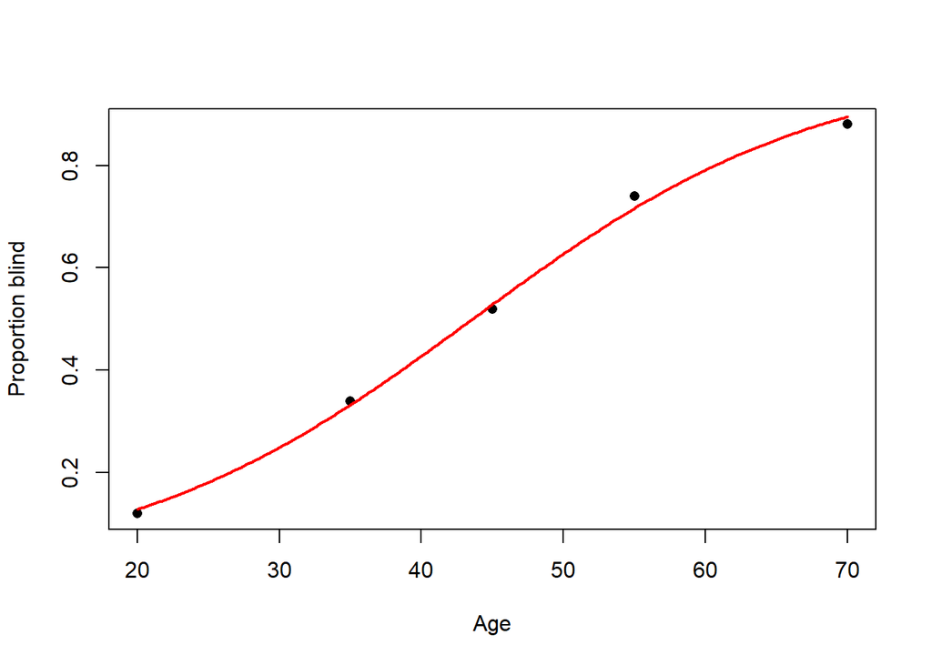

```r
Kalythos$p_obs <- Kalythos$n_blind / Kalythos$total_sample

age_seq <- seq(min(Kalythos$age), max(Kalythos$age), length.out = 200)

pred <- predict(fit, newdata = data.frame(age = age_seq),
                type = "response")

plot(Kalythos$age, Kalythos$p_obs,
     xlab = "Age",
     ylab = "Proportion blind",
     pch = 16)

lines(age_seq, pred, col = "red", lwd = 2)
```

### 3. Compute a confidence interval for the probability that an individual on the island is blind at ages 20, 50, and 70. Use a 90% confidence level.

```r
nd <- data.frame(age = c(20, 50, 70))

pred <- predict(fit, newdata=nd, type="link", se.fit=TRUE)

cbind(binomial()$linkinv(pred$fit + qnorm(.05) * pred$se.fit),
      binomial()$linkinv(pred$fit + qnorm(.95) * pred$se.fit))
```

```
##         [,1]      [,2]
## 1 0.08216859 0.1951734
## 2 0.56247042 0.6872294
## 3 0.83498665 0.9347823
```

### 4. Perform a test to check whether the value of the coefficient associated with the predictor age is equal to 0.1. Use a significance level of 10%.

```r
summary(fit)$coef
```

```
##                Estimate Std. Error   z value     Pr(>|z|)
## (Intercept) -3.53777987 0.50232451 -7.042817 1.883909e-12
## age          0.08113952 0.01082122  7.498186 6.470690e-14
```

```r
confint(fit, parm = "age", level = 0.90)
```

```
## In attesa che venga eseguita la profilazione...
```

```
##        5 %       95 %
## 0.06410088 0.09980226
```

Since 0.1 is **outside** of the interval, at significance of 10% we reject the null hypothesis $H_0:\ \beta_{\text{age}} = 0.1$.

### 6. Use the two variables specified below as predictors in a model that investigates how the proportion of blind people on the island changes as a function of individuals’ age. Compare the estimated coefficient values: what interpretation can be given to the estimate of the intercept in the different models?

```r
Kalythos$age_m20 <- Kalythos$age-20
Kalythos$age_m45 <- Kalythos$age-45


fit2 <- glm(Y ~ age_m20, family = binomial, data = Kalythos)
summary(fit2)
```

```
##
## Call:
## glm(formula = Y ~ age_m20, family = binomial, data = Kalythos)
##
## Coefficients:
##             Estimate Std. Error z value Pr(>|z|)
## (Intercept) -1.91499    0.30292  -6.322 2.58e-10 ***
## age_m20      0.08114    0.01082   7.498 6.47e-14 ***
## ---
## Signif. codes:  0 '***' 0.001 '**' 0.01 '*' 0.05 '.' 0.1 ' ' 1
##
## (Dispersion parameter for binomial family taken to be 1)
##
##     Null deviance: 82.14455  on 4  degrees of freedom
## Residual deviance:  0.31707  on 3  degrees of freedom
## AIC: 24.132
##
## Number of Fisher Scoring iterations: 4
```

```r
fit3 <- glm(Y ~ age_m45, family = binomial, data = Kalythos)
summary(fit3)
```

```
##
## Call:
## glm(formula = Y ~ age_m45, family = binomial, data = Kalythos)
##
## Coefficients:
##             Estimate Std. Error z value Pr(>|z|)
## (Intercept)  0.11350    0.15093   0.752    0.452
## age_m45      0.08114    0.01082   7.498 6.47e-14 ***
## ---
## Signif. codes:  0 '***' 0.001 '**' 0.01 '*' 0.05 '.' 0.1 ' ' 1
##
## (Dispersion parameter for binomial family taken to be 1)
##
##     Null deviance: 82.14455  on 4  degrees of freedom
## Residual deviance:  0.31707  on 3  degrees of freedom
## AIC: 24.132
##
## Number of Fisher Scoring iterations: 4
```

By centering age at 20 or 45 in separate models, the slope remains the same but the intercept changes its meaning: in the model with `age_m20` it represents the log-odds (and thus the probability) of being blind at age 20, while in the model with `age_m45` it represents the log-odds of being blind at age 45, making the intercept directly interpretable as the baseline risk at the chosen reference age.